# Partial review on work of week 1

Steve Shao

From 5.13 to 5.17

I tried working on some basic analyses using data from Xianyuan and Disney (a single round trip of a single vehicle for both cases), focusing on **pitch** where we want to recover the true pitch information of the track as much as possible.

The problem is that there are jitters caused by bumpers and "abrupt brake/throttle".

# Visualization attempt

```python
import numpy as np
import pandas as pd
import scipy as sp
import re
import matplotlib.pyplot as plt
import seaborn as sns
from mpl_toolkits.mplot3d import Axes3D

def to_num(s):
    try:
        return int(s)
    except ValueError:
        try:
            return float(s)
        except ValueError:
            return s

# Moving Average
def MA(seq, w):
    """
    Moving average
    seq: sequence; w: window size
    """
    out0 = np.convolve(seq,np.ones(w,dtype=int),'valid')/w
    r = np.arange(1,w-1,2)
    start = np.cumsum(seq[:w-1])[::2]/r
    stop = (np.cumsum(seq[:-w:-1])[::2]/r)[::-1]
    return np.concatenate((  start , out0, stop  ))
```

```python
res = []
with open('test2.log', 'r') as lines:
    numRows = 0
    tmp = []
    for line in lines:
        if line.strip() != '---':
            if len((line.strip().split(':'))[1].strip()):
                tmp.append(to_num((line.strip().split(':'))[1].strip()))
        else:
            res.append(tmp)
            tmp = []


cols = ['seq', 'secs', 'nsecs', 'frame_id', 'utm_east', 'utm_north',
       'utm_up', 'roll', 'pitch', 'yaw', 'velo_north',
       'velo_east', 'velo_down', 'velo_robot_x',
       'velo_robot_y', 'velo_robot_z', 'acc_robot_x',
       'acc_robot_y', 'acc_robot_z', 'omega_yaw', 'omega_pitch',
       'omega_roll', 'nav_mode', 'pos_mode', 'vel_mode']

df = pd.DataFrame(res, columns=cols)
df = df.drop(columns = ['seq', 'frame_id'])
```

```python
x = df.utm_east
y = df.utm_north
z = df.utm_up
roll = df.roll
pitch = df.pitch
yaw = df.yaw
```

### Erase bias

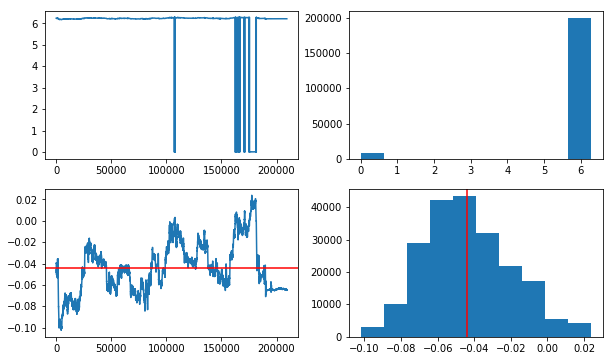

```python
pitch_s = np.sin(pitch)
plt.figure(figsize=(10,6))
plt.subplot(221)
plt.plot((df.pitch))
plt.subplot(222)
plt.hist((df.pitch))
plt.subplot(223)
plt.plot(pitch_s)
plt.axhline(np.mean(pitch_s), c='red')
plt.subplot(224)
plt.hist(pitch_s)
plt.axvline(np.mean(pitch_s), c='red');
```

```python
pitch2 = pitch.copy()
pitch2[pitch>np.pi] = 2*np.pi - pitch[pitch>np.pi]
pitch2[pitch<=np.pi] = - pitch[pitch<=np.pi]
shift = 0.04 # approximate shift
pitch2 = pitch2 - shift
```

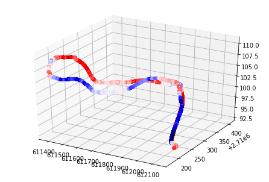

```python
fig=plt.figure()
ax = Axes3D(fig)
# ax.set_aspect('equal')
ax.scatter(x, y, MA(z,10001), c=pitch2, cmap='seismic');
```

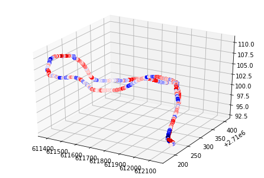

```python
pitch_noise = pitch2 - MA(pitch2, 10001)
fig=plt.figure()
ax = Axes3D(fig)
# ax.set_aspect('equal')
ax.scatter(x, y, MA(z,10001), c=pitch_noise, cmap='seismic');
```

### locate and remove asymmetric track

```python
n_s = 0 # starting
n_h = np.array(df.utm_east).argmin() # half
n_e = np.where(df.utm_east>df.utm_east[0])[0][0] - 1 # ending
```

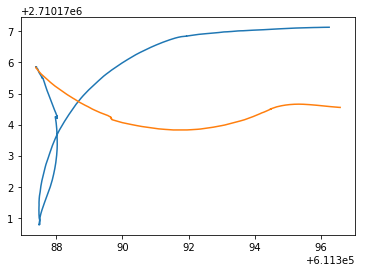

```python
# locate the asymmetric track part
plt.plot(df.utm_east[n_h-7000:n_h], df.utm_north[n_h-7000:n_h])
plt.plot(df.utm_east[n_h:n_h+3900], df.utm_north[n_h:n_h+3900]);
```

```python
n1_s = n_s
n1_e = n_h-7000
n2_s = n_h+3900
n2_e = n_e
n1 = list(range(n1_s, n1_e)) # idx of first half
n2 = list(range(n2_s, n2_e)) # idx of second half
```

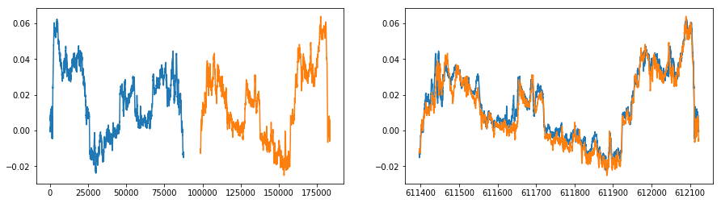

```python
plt.figure(figsize=(15,4))
plt.subplot(121)
plt.plot(pitch2[n1])
plt.plot(-pitch2[n2])
plt.subplot(122)
plt.plot(x[n1], pitch2[n1])
plt.plot(x[n2], -pitch2[n2]);
```

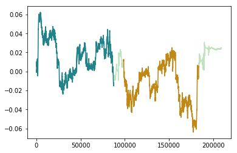

```python
plt.plot(pitch2[n1])
plt.plot(pitch2[n2])
plt.plot(pitch2, alpha=0.3)
```

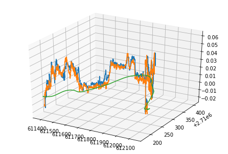

```python
fig=plt.figure()
ax = Axes3D(fig)
ax.plot(x[n1], y[n1], pitch2[n1])
ax.plot(x[n2], y[n2], -pitch2[n2])
ax.plot(x[n_h:], y[n_h:], 0);
```

# Decompose observed pitch and restore true pitch

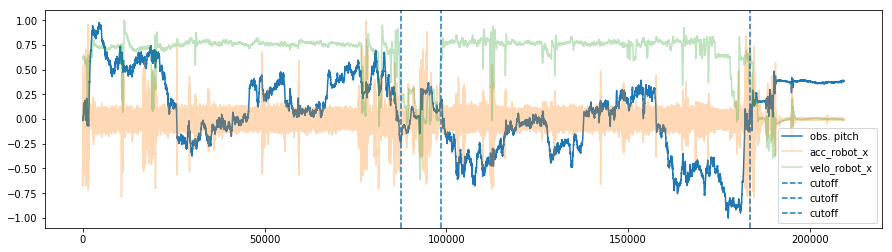

```python
#### max abs normalization
pitch2_tmp = pitch2/abs(pitch2).max()
acc_x_tmp = df.acc_robot_x/abs(df.acc_robot_x).max()
velo_x_tmp = df.velo_robot_x/abs(df.velo_robot_x).max()

plt.figure(figsize=(15,4))
plt.plot(pitch2_tmp, label='obs. pitch')
plt.plot(acc_x_tmp, alpha=0.3, label='acc_robot_x')
plt.plot(velo_x_tmp, alpha=0.3, label='velo_robot_x')
plt.axvline(n1_e, ls='--', label='cutoff')
plt.axvline(n2_s, ls='--', label='cutoff')
plt.axvline(n_e, ls='--', label='cutoff')
plt.legend();
```

This plot kind of shows the main framework in my mind so far. (For simplicity, many other plots are omitted)

The details are as follows:

#### Intro

- The blue line is the observed pitch, green line the robot velocity, orange line the robot acceleration.
- I shifted the observed pitch to erase the potential bias.
- I located the symmetric track and based most of my analyses on them.

#### observation

- The abrupt change of velocity corresponds to large value of acceleration (for sure), which would lead to larger amplitude of observed pitch in general.
- Large value of acceleration with no obvious change in velocity might suggest a huge bumper which causes greater jitters in our observation.
- The track we travelled is strongly symmetric, which can be used in later analyses to identify the true pitch.

#### Framework

- quantify the effect of acc
- filter out the effect of motion of vehicle
- filter out the bumper effect (ideally would be symmetric) by a low pass filter
- Interpolate/estimate the pitch of asymmetric part.

*combind data from multiple vehicles and multiple trials*